# Lakers Report

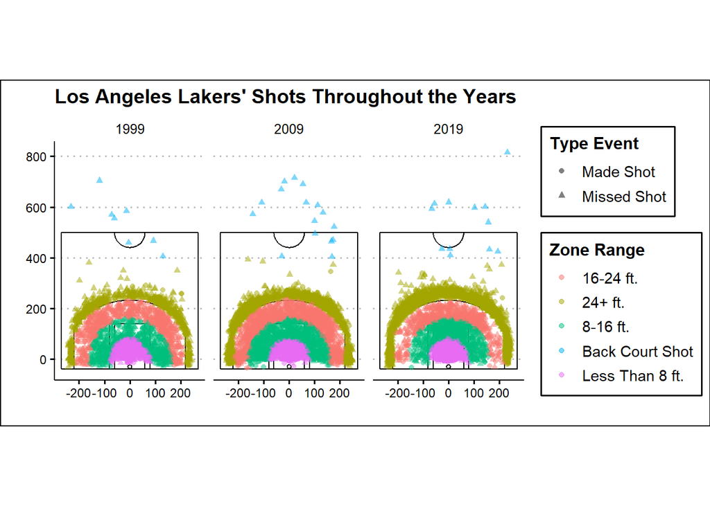

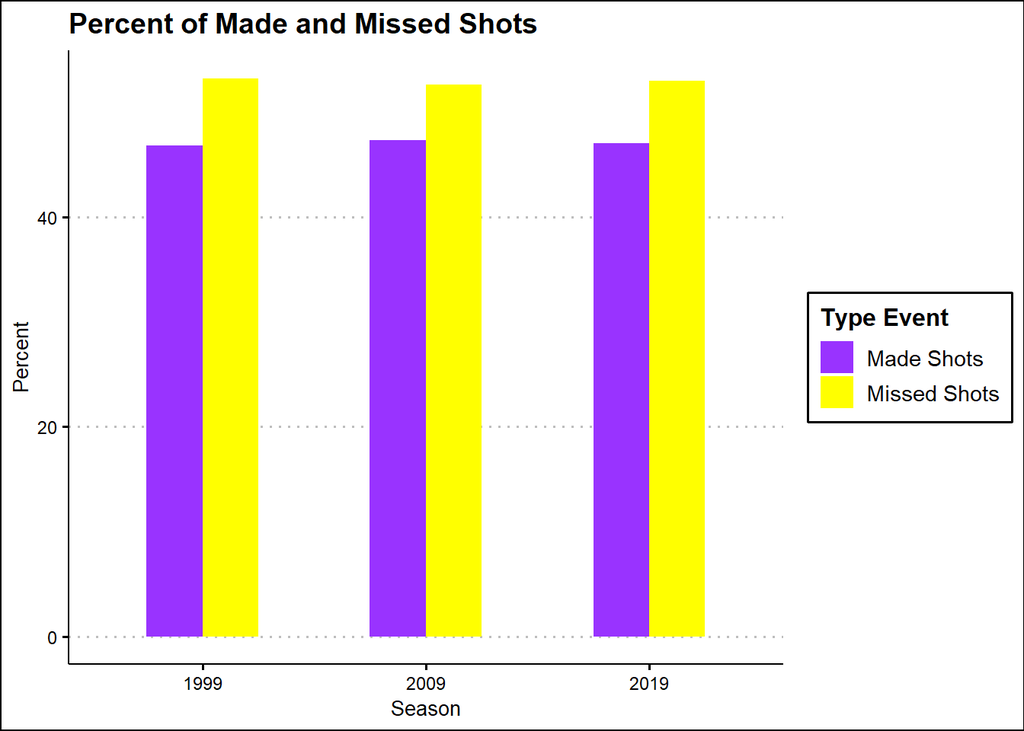

Report:

- The court graphic looks at the team shots of the Lakers from three seasons: 1999, 2009, and 2019.
- The shots made is represented by a circle and the shots missed is represented by a triangle.
- From where on the court the player made the shot is represented by different colors. The different zone ranges and colors are shown in the legend made in the graphic.
- As the years go on, it appears that the players are shooting further away from the hoop. The purple region on each graphic (the less than 8 feet range), appears to get less dense as the years proceed.
- In the bar graph the percents of the made and missed shots of each season is shown
- The bar graph does not show a notable change in the made and missed shots throughout the years.

This graphic is showing the different average heights from the same seasons that the other two graphics look at. I wanted to see if there is some correlation between the percent of shots made and the average player height from each of the seasons looked at. There is no notable difference between the made shots throughout the seasons and there is no notable height difference throughout the seasons as well.

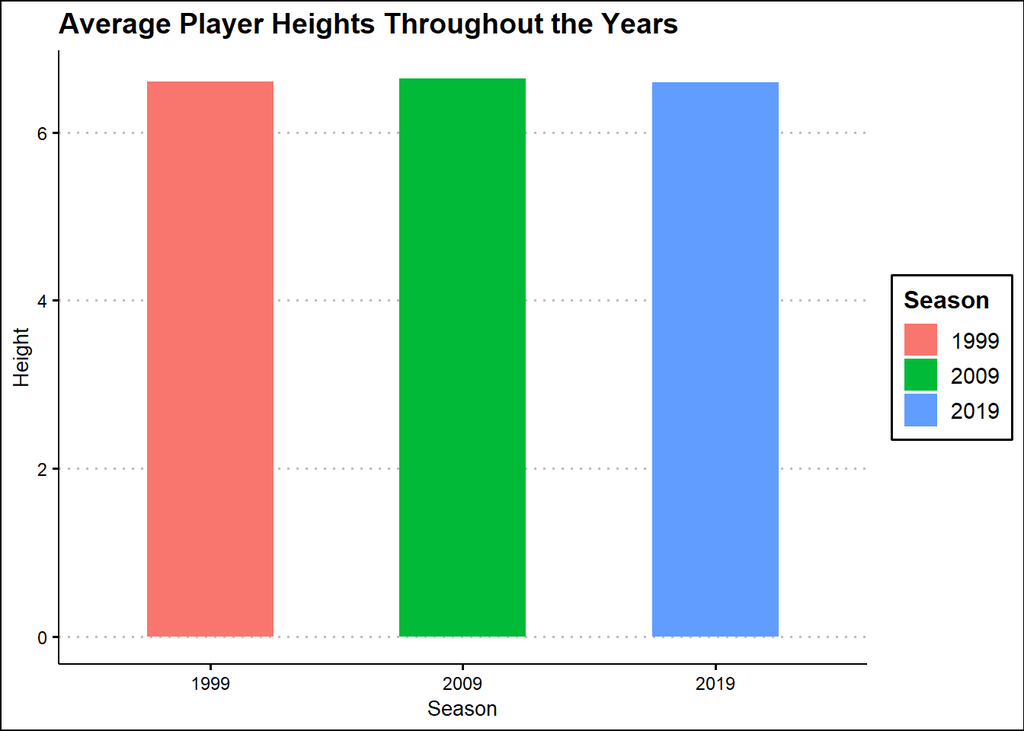